# Time Series Analysis

#### Homework3 201811526 이은주

### Data

```r
data = read.csv('loadregr.csv') #find a proper directory for your data.
(data_ts = ts(data$MKw, start=c(1970, 1), end=c(1979, 12), frequency=12 ))
```

```
##          Jan     Feb     Mar     Apr     May     Jun     Jul     Aug     Sep
## 1970 6.60110 6.55576 6.51810 6.42498 6.43868 6.48173 6.71284 6.64639 6.51100
## 1971 6.70224 6.65245 6.58104 6.50932 6.51981 6.64591 6.77194 6.71382 6.60164
## 1972 6.77956 6.75018 6.66494 6.56197 6.57278 6.85069 6.76831 6.75746 6.71462
## 1973 6.85132 6.85432 6.75464 6.69287 6.71209 6.79801 6.90086 6.95501 6.78619
## 1974 6.94209 6.90815 6.79581 6.77106 6.76630 6.92218 7.02025 7.02929 6.81991
## 1975 6.97866 6.94202 6.87909 6.79965 6.81259 6.89272 7.16972 6.93213 6.82103
## 1976 7.04580 7.06250 6.99577 6.89578 6.86417 6.99927 7.16027 7.11666 6.89878
## 1977 7.14766 7.05902 7.00532 6.89115 6.89297 7.01257 7.19739 7.09346 6.96310
## 1978 7.29256 7.13518 7.00859 6.95518 7.01947 7.13228 7.29528 7.09632 7.02693
## 1979 7.32306 7.30641 7.17916 7.02096 7.04144 7.17437 7.26813 7.24400 7.18675
##          Oct     Nov     Dec
## 1970 6.51021 6.58769 6.61386
## 1971 6.58158 6.61455 6.70228
## 1972 6.64869 6.70601 6.75843
## 1973 6.77511 6.84878 6.96915
## 1974 6.80915 6.88408 6.91290
## 1975 6.85578 6.95368 6.99520
## 1976 6.93408 6.97616 7.07897
## 1977 7.02267 7.09898 7.19206
## 1978 7.01620 7.11002 7.23462
## 1979 7.12274 7.17493 7.27526
```

1970년 1월부터 1979년 12월까지의 Iowa state의 electricity data입니다.

### 1. Draw time series plot

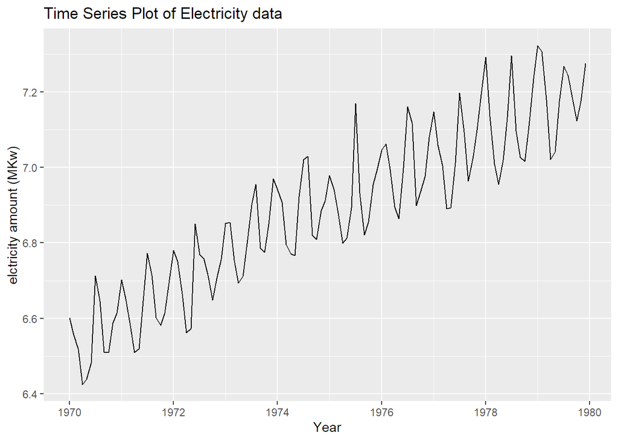

```r
data_ts %>%
  autoplot() +
  ggtitle("Time Series Plot of Electricity data") +
  xlab("Year") + ylab("elctricity amount (MKw)")
```

- 위의 time series plot을 보면 시간이 흐를수록 증가하는 추세를 볼 수 있고  
  일정 기간마다 상승 및 하강을 이루는 계절성을 보임을 알 수 있습니다. 이에 따라 추세성, 계절성, 잔차에 대해 decomposition해 볼 필요가 있음을 알 수 있습니다.

### 2. Fit decomposition model and draw a plot with the original data, seasonally adjusted, trend-cycle component all together.

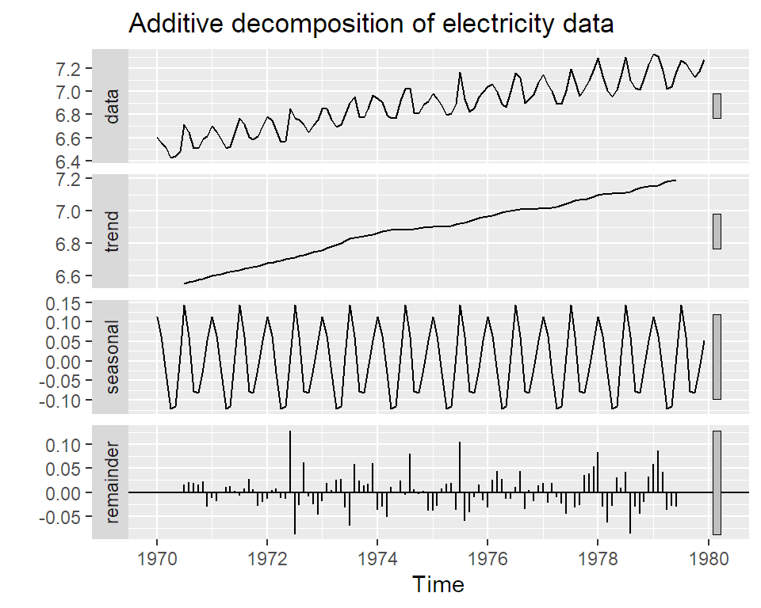

```r
dec_add = decompose(data_ts, type="additive")
dec_add %>%
  autoplot() +
  ggtitle("Additive decomposition of electricity data")
```

```r
#diagonosis
tseries::kpss.test(dec_add$random, null="Level")
```

```
##
##  KPSS Test for Level Stationarity
##
## data:  dec_add$random
## KPSS Level = 0.00040235, Truncation lag parameter = 4, p-value = 0.1
```

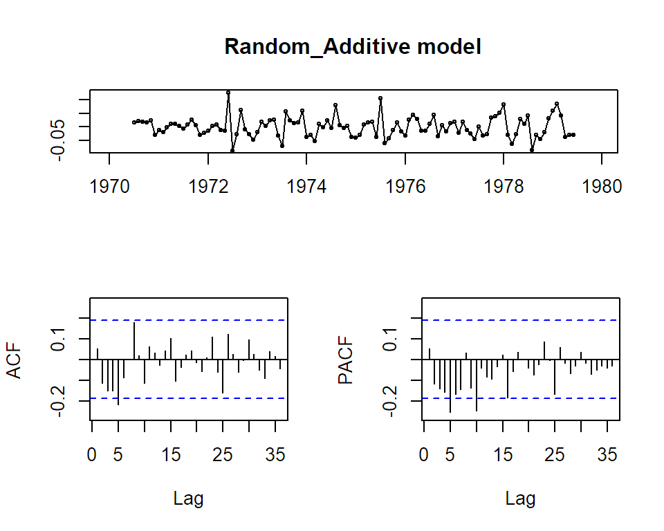

```r
tsdisplay(dec_add$random, main="Random_Additive model")
```

2. classical multiplicative decomposition

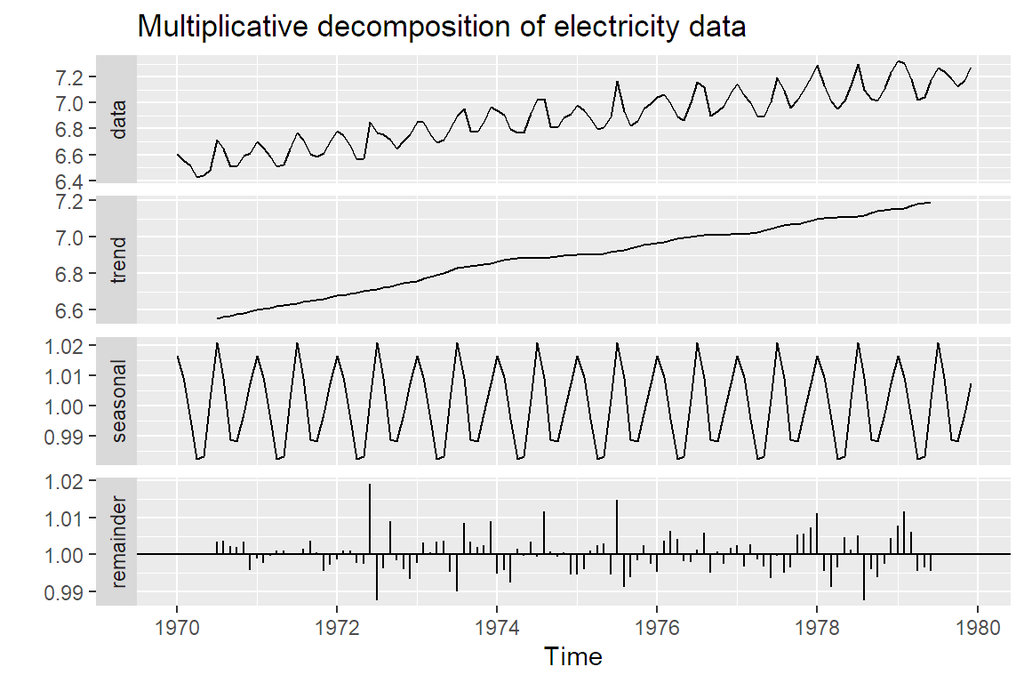

```r
dec_mul = decompose(data_ts, type="multiplicative")
dec_mul %>%
  autoplot() +
  ggtitle("Multiplicative decomposition of electricity data")
```

```r
#diagonosis
tseries::kpss.test(dec_mul$random, null="Level")
```

```
##
##  KPSS Test for Level Stationarity
##
## data:  dec_mul$random
## KPSS Level = 0.024423, Truncation lag parameter = 4, p-value = 0.1
```

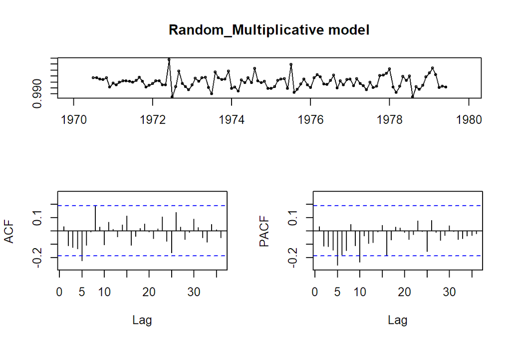

```r
tsdisplay(dec_mul$random, main="Random_Multiplicative model")
```

3. SEATS decomposition

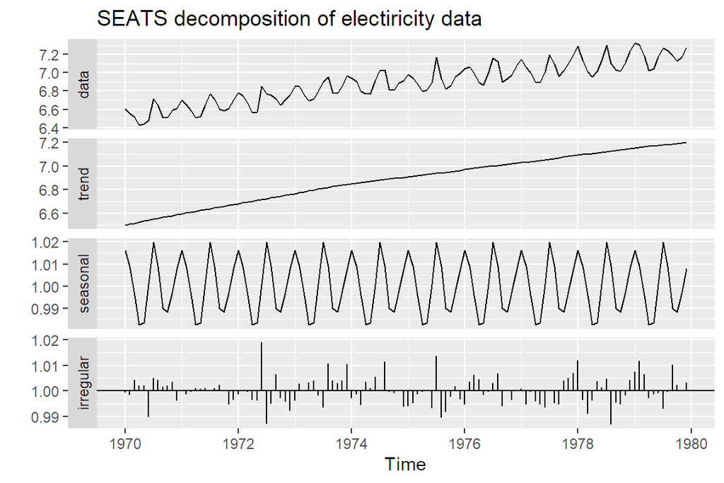

```r
dec_seas = seas(data_ts)
dec_seas %>%
  autoplot() +
  ggtitle("SEATS decomposition of electiricity data")
```

```r
#diagonosis
tseries::kpss.test(dec_seas$data[,"irregular"], null="Level")
```

```
##
##  KPSS Test for Level Stationarity
##
## data:  dec_seas$data[, "irregular"]
## KPSS Level = 0.049134, Truncation lag parameter = 4, p-value = 0.1
```

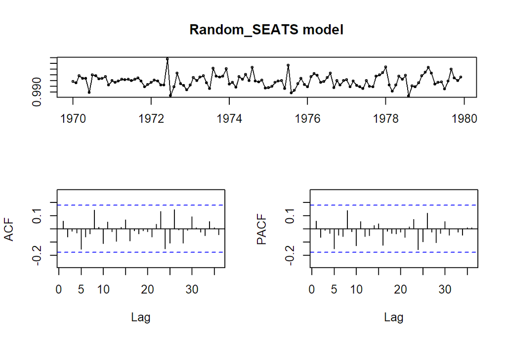

```r
tsdisplay(dec_seas$data[,"irregular"], null="Level", main="Random_SEATS model")
```

4. X11 decomposition

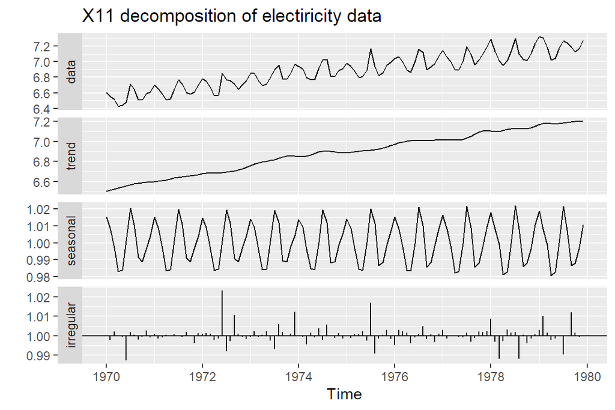

```r
dec_x11 = seas(data_ts, x11="")
dec_x11 %>%
  autoplot() +
  ggtitle("X11 decomposition of electiricity data")
```

```r
#diagonosis
tseries::kpss.test(dec_x11$data[,"irregular"], null="Level")
```

```
##
##  KPSS Test for Level Stationarity
##
## data:  dec_x11$data[, "irregular"]
## KPSS Level = 0.085333, Truncation lag parameter = 4, p-value = 0.1
```

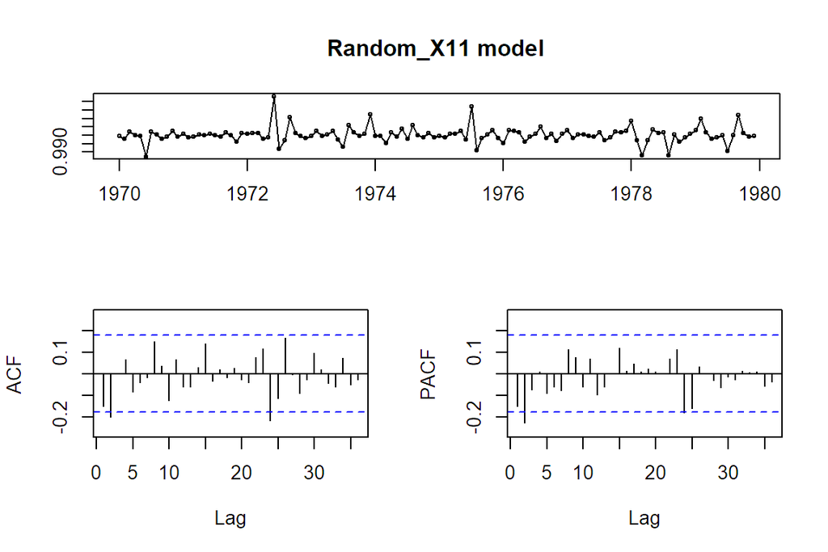

```r
tsdisplay(dec_x11$data[,"irregular"], null="Level", main="Random_X11 model")
```

5. STL decomposition

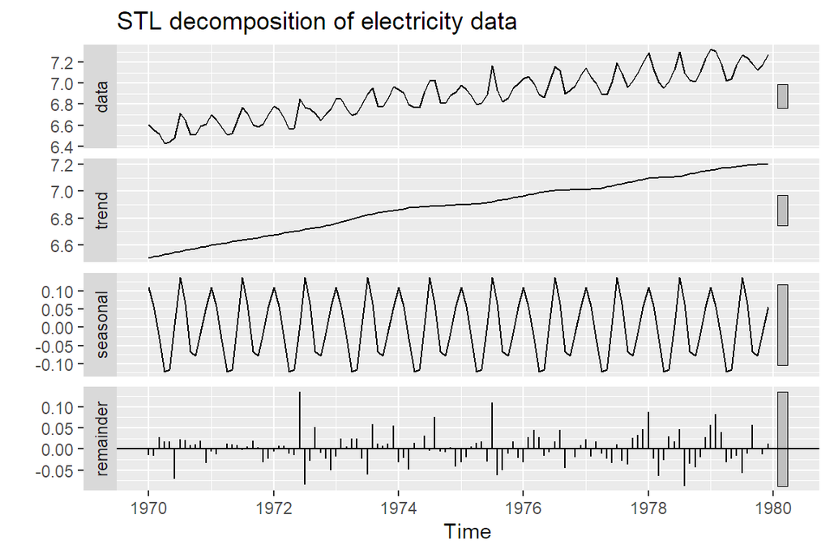

```r
dec_stl = stl(data_ts, "periodic")
dec_stl %>%
  autoplot() +
  ggtitle("STL decomposition of electricity data")
```

```r
#diagonosis
tseries::kpss.test(dec_stl$time.series[,"remainder"], null="Level")
```

```
##
##  KPSS Test for Level Stationarity
##
## data:  dec_stl$time.series[, "remainder"]
## KPSS Level = 0.015404, Truncation lag parameter = 4, p-value = 0.1
```

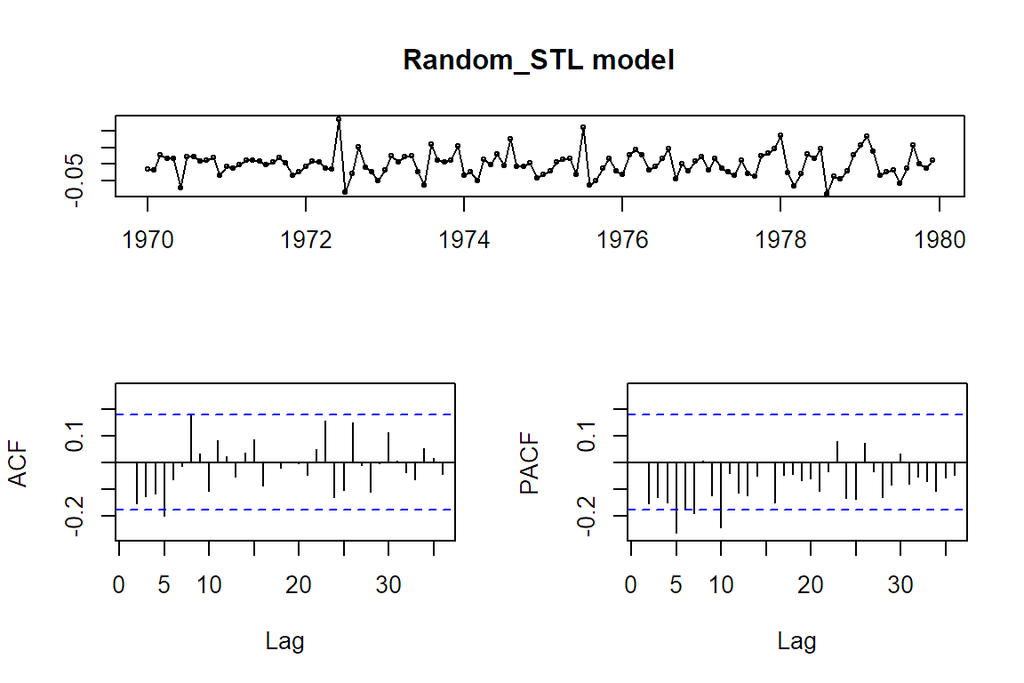

```r
tsdisplay(dec_stl$time.series[,"remainder"], null="Level", main="Random_STL model")
```

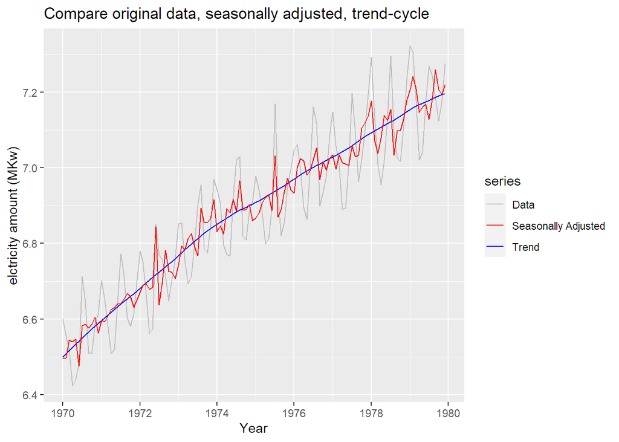

```r
autoplot(data_ts, series="Data") +
  autolayer(trendcycle(dec_seas), series="Trend") +
  autolayer(seasadj(dec_seas), series="Seasonally Adjusted") +
  xlab("Year") + ylab("elctricity amount (MKw)") +
  ggtitle("Compare original data, seasonally adjusted, trend-cycle") +
  scale_colour_manual(values=c("gray","red","blue"),
                      breaks=c("Data","Seasonally Adjusted","Trend"))
```

- blue line : electricity data의 trend를 나타내는 것으로 시간이 지날수록 상승세를 보입니다.
- red line : electricity data에서 계절성만을 제외하고, trend와 remainder만을 그린 것으로  
  gray line과 비교하였을 때, original data에서 계절성이 어느 정도 사라진 것을 알 수 있습니다.

### 3. Draw sub-series seasonal effect graph in each month.

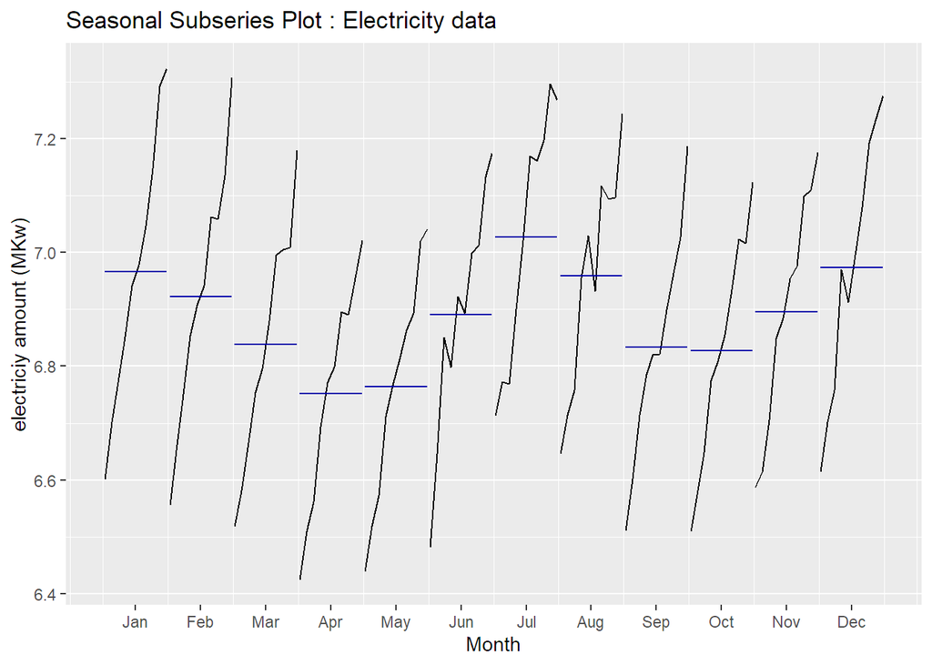

```r
data_ts %>%
  ggsubseriesplot() +
  ylab("electriciy amount (MKw)") +
  ggtitle("Seasonal Subseries Plot : Electricity data")
```

- Seasonal Subseries Plot은 데이터의 계절성을 확인하기 위해 1970년부터 1979년까지의 데이터를 달(month)별로 함축한 것입니다.  
  위의 그래프에 따르면, 우선 12월~2월(겨울)에 전기량이 높은 것을 볼 수 있습니다.  
  이후 4-5월까지 전기량이 줄어들다가 다시 7~8월(여름)에는 전기량이 증가하는 것을 알 수 있습니다.  
  또한, 9~10월에 다시 전기량이 줄어들며 겨울이 다가오면서 또다시 전기량이 높아집니다.  
  즉, 달별로 수준의 차이가 있으며 이에 따라 계절성이 존재한다는 것을 알 수 있습니다.

### 4. Draw a polar seasonal plot.

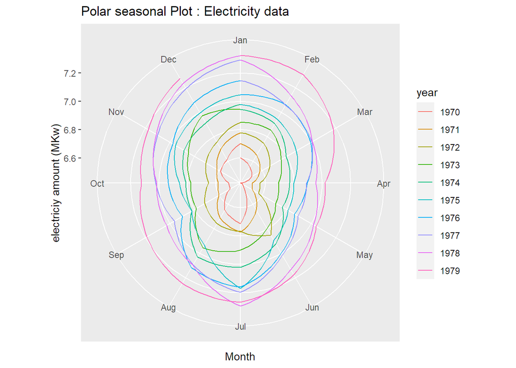

```r
data_ts %>%
  ggseasonplot(polar=TRUE) +
  ylab("electriciy amount (MKw)") +
  ggtitle("Polar seasonal Plot : Electricity data")
```

- Polar Seasonal Plot은 각 달별 전기량을 polar coordinate system(극좌표계)에 연도별로 나타낸 것입니다.  
  위의 그래프를 보면, 연도가 증가할수록 원형이 커지므로 전기사용량이 증가하는 것을 알 수 있습니다.  
  또한, 대체적인 원의 모양을 보면 12~2월, 6~8월에 전기사용량을 많으며, 3~5월, 9~11월에는 전기사용량이 적은 것을 알 수 있습니다.  
  즉, 연도가 증가할수록 전기사용량이 증가하는 추세이며 특히 여름과 겨울에 전기사용량이 높습니다.